# Auto Insurance Fraud Claim Identification Prediction

## **Goal of the Project**

#### - Develop a model that identifies high potential fraud claims in order to minimize future financial loss (of the insurance company)

## **Project's Framework**

#### **1. Understand the insurance claim data (Exploratory Data Analysis EDA)**

#### **2. Prepare data to build a model**

#### **3. Develop model performance measurements**

#### **4. Apply classification models to the data**

##### -- Deep learning techniques are not applied in this project as the dataset is not huge and is already in structured format.

##### Logistic regression

##### KNN (K Nearest Neighbor)

##### Linear Discriminant Analysis (LDA)

##### Quadratic Discriminant Analysis (QDA)

##### Decision Tree

##### Random Forest

##### Ada Boost Classifier

##### Gradient Boosting Classifier

##### Extreme Gradient Boosting (XGBoost) Classifier

#### **5. Compare performances of the above models and identify a strong candidate models**

#### **6. Tune hyperparameters of the chosen models (if possible)**

#### **7. Choose the final model and identify the relative importance of input variables to predict a fraud claims**

#### **7. Identify relatively importance of the input information to predict fraud claims with a final model**

#### **8. Develop business recommendations**

## **Findings**

#### **1. Fraud_report Y=25%. This is an unbalanced data.**

#### **2. Because the purpose of this project is to reduce the false negative case, a recall rate is selected as the main measurement for model performances.**

#### **3. After hyperparameter tunning, Gradient Boosting Classifier performs the best with the test data recall rate 86%**

#### **4. Interestingly, main predictors are: Incident_severity (especially when the values are total loss or minor damage), Insured_hobbies (especially when the values are chess or cross-fit) and Vehicle_Claim amount.**

### **Data Source**

#### Insurance Fraud Detection data from Kaggle - https://www.kaggle.com/datasets/arpan129/insurance-fraud-detection

### Import libraries.

```python
# Libraries to help with reading and manipulating data
import pandas as pd
import numpy as np

# Libaries to help with data visualization
import matplotlib.pyplot as plt
import seaborn as sns

#### Algorithms for Regression

# To tune model, get different metric scores, and split data
from sklearn import metrics
from sklearn.metrics import r2_score, mean_squared_error, mean_absolute_error

from sklearn.model_selection import train_test_split, StratifiedKFold, cross_val_score

# To be used for data scaling and one hot encoding
from sklearn.preprocessing import StandardScaler, MinMaxScaler, OneHotEncoder

# To impute missing values
from sklearn.impute import SimpleImputer

# To do hyperparameter tuning
from sklearn.model_selection import RandomizedSearchCV

# To be used for creating pipelines and personalizing them
from sklearn.pipeline import Pipeline
from sklearn.compose import ColumnTransformer

# To define maximum number of columns to be displayed in a dataframe
pd.set_option("display.max_columns", None)

# To suppress scientific notations for a dataframe
pd.set_option("display.float_format", lambda x: "%.3f" % x)

# To help with model building
from sklearn.tree import DecisionTreeRegressor
from sklearn.ensemble import (
    BaggingRegressor,
    RandomForestRegressor,
    GradientBoostingRegressor,
    AdaBoostRegressor,
    StackingRegressor,
)
from xgboost import XGBRegressor



#### Algorithms for Classification
# To scale the data using z-score
from sklearn.preprocessing import StandardScaler

from sklearn.model_selection import train_test_split

# Algorithms to use
from sklearn.discriminant_analysis import LinearDiscriminantAnalysis

from sklearn.discriminant_analysis import QuadraticDiscriminantAnalysis

from sklearn.linear_model import LogisticRegression

from sklearn.neighbors import KNeighborsClassifier

from sklearn import tree

from sklearn.tree import DecisionTreeClassifier

from sklearn.ensemble import RandomForestClassifier

#!pip install xgboost
# Importing the AdaBoostClassifier and GradientBoostingClassifier [Boosting]
from sklearn.ensemble import AdaBoostClassifier, GradientBoostingClassifier

# Importing the XGBClassifier from the xgboost library
from xgboost import XGBClassifier

# Metrics to evaluate the model
from sklearn.metrics import confusion_matrix, classification_report, precision_recall_curve,recall_score,precision_score, accuracy_score,f1_score

# For tuning the model
from sklearn.model_selection import GridSearchCV

# to display relative importance of variables in a model
#!pip install shap
import shap as sh

# To suppress scientific notations
pd.set_option("display.float_format", lambda x: "%.3f" % x)

# To suppress warnings
import warnings

warnings.filterwarnings("ignore")

# to understand important variables
#  !pip install shap
# Importing the SHAP library
import shap as sh
```

### Explore/Understand Data.

```python
# read data:
data = pd.read_excel('../input/insurance-fraud-detection/Worksheet in Case Study question 2.xlsx')
```

```python
# Checking the number of rows and columns in the training data
data.shape
```

```
(1000, 39)
```

```python
data.head()
```

|  | months_as_customer | age | policy_number | policy_bind_date | policy_state | policy_csl | policy_deductable | policy_annual_premium | umbrella_limit | insured_zip | insured_sex | insured_education_level | insured_occupation | insured_hobbies | insured_relationship | capital-gains | capital-loss | incident_date | incident_type | collision_type | incident_severity | authorities_contacted | incident_state | incident_city | incident_location | incident_hour_of_the_day | number_of_vehicles_involved | property_damage | bodily_injuries | … |
| --- | --- | --- | --- | --- | --- | --- | --- | --- | --- | --- | --- | --- | --- | --- | --- | --- | --- | --- | --- | --- | --- | --- | --- | --- | --- | --- | --- | --- | --- | --- |
| 0 | 328 | 48 | 521585 | 2014-10-17 | OH | 250/500 | 1000 | 1406.910 | 0 | 466132 | MALE | MD | craft-repair | sleeping | husband | 53300 | 0 | 2015-01-25 | Single Vehicle Collision | Side Collision | Major Damage | Police | SC | Columbus | 9935 4th Drive | 5 | 1 | YES | 1 | … |
| 1 | 228 | 42 | 342868 | 2006-06-27 | IN | 250/500 | 2000 | 1197.220 | 5000000 | 468176 | MALE | MD | machine-op-inspct | reading | other-relative | 0 | 0 | 2015-01-21 | Vehicle Theft | ? | Minor Damage | Police | VA | Riverwood | 6608 MLK Hwy | 8 | 1 | ? | 0 | … |
| 2 | 134 | 29 | 687698 | 2000-09-06 | OH | 100/300 | 2000 | 1413.140 | 5000000 | 430632 | FEMALE | PhD | sales | board-games | own-child | 35100 | 0 | 2015-02-22 | Multi-vehicle Collision | Rear Collision | Minor Damage | Police | NY | Columbus | 7121 Francis Lane | 7 | 3 | NO | 2 | … |
| 3 | 256 | 41 | 227811 | 1990-05-25 | IL | 250/500 | 2000 | 1415.740 | 6000000 | 608117 | FEMALE | PhD | armed-forces | board-games | unmarried | 48900 | -62400 | 2015-01-10 | Single Vehicle Collision | Front Collision | Major Damage | Police | OH | Arlington | 6956 Maple Drive | 5 | 1 | ? | 1 | … |
| 4 | 228 | 44 | 367455 | 2014-06-06 | IL | 500/1000 | 1000 | 1583.910 | 6000000 | 610706 | MALE | Associate | sales | board-games | unmarried | 66000 | -46000 | 2015-02-17 | Vehicle Theft | ? | Minor Damage | None | NY | Arlington | 3041 3rd Ave | 20 | 1 | NO | 0 | … |

```python
data.tail()
```

|  | months_as_customer | age | policy_number | policy_bind_date | policy_state | policy_csl | policy_deductable | policy_annual_premium | umbrella_limit | insured_zip | insured_sex | insured_education_level | insured_occupation | insured_hobbies | insured_relationship | capital-gains | capital-loss | incident_date | incident_type | collision_type | incident_severity | authorities_contacted | incident_state | incident_city | incident_location | incident_hour_of_the_day | number_of_vehicles_involved | property_damage | bodily_injuries | … |
| --- | --- | --- | --- | --- | --- | --- | --- | --- | --- | --- | --- | --- | --- | --- | --- | --- | --- | --- | --- | --- | --- | --- | --- | --- | --- | --- | --- | --- | --- | --- |
| 995 | 3 | 38 | 941851 | 1991-07-16 | OH | 500/1000 | 1000 | 1310.800 | 0 | 431289 | FEMALE | Masters | craft-repair | paintball | unmarried | 0 | 0 | 2015-02-22 | Single Vehicle Collision | Front Collision | Minor Damage | Fire | NC | Northbrook | 6045 Andromedia St | 20 | 1 | YES | 0 | … |
| 996 | 285 | 41 | 186934 | 2014-01-05 | IL | 100/300 | 1000 | 1436.790 | 0 | 608177 | FEMALE | PhD | prof-specialty | sleeping | wife | 70900 | 0 | 2015-01-24 | Single Vehicle Collision | Rear Collision | Major Damage | Fire | SC | Northbend | 3092 Texas Drive | 23 | 1 | YES | 2 | … |
| 997 | 130 | 34 | 918516 | 2003-02-17 | OH | 250/500 | 500 | 1383.490 | 3000000 | 442797 | FEMALE | Masters | armed-forces | bungie-jumping | other-relative | 35100 | 0 | 2015-01-23 | Multi-vehicle Collision | Side Collision | Minor Damage | Police | NC | Arlington | 7629 5th St | 4 | 3 | ? | 2 | … |
| 998 | 458 | 62 | 533940 | 2011-11-18 | IL | 500/1000 | 2000 | 1356.920 | 5000000 | 441714 | MALE | Associate | handlers-cleaners | base-jumping | wife | 0 | 0 | 2015-02-26 | Single Vehicle Collision | Rear Collision | Major Damage | Other | NY | Arlington | 6128 Elm Lane | 2 | 1 | ? | 0 | … |
| 999 | 456 | 60 | 556080 | 1996-11-11 | OH | 250/500 | 1000 | 766.190 | 0 | 612260 | FEMALE | Associate | sales | kayaking | husband | 0 | 0 | 2015-02-26 | Parked Car | ? | Minor Damage | Police | WV | Columbus | 1416 Cherokee Ridge | 6 | 1 | ? | 0 | … |

#### --> Finding: It looks like policy_number, incident_location, insured_zip,policy_bind_date, incident_date would not add value to predict the fraud claim. Let's drop them.

```python
data1 = data.drop(["policy_number","incident_location","insured_zip","policy_bind_date","incident_date"], axis=1)
#replace ? with NaN
data1=data1.replace('?',np.NaN)
```

```python
# let's convert the autoyear to auto_age
data1["auto_age"]=2023-data1["auto_year"]
data1=data1.drop(["auto_year"],axis=1)
```

### Summary Statistics

```python
#selecting numeric columns and generating the summary statistics
num_col = data1.select_dtypes('number').columns
data1[num_col].describe().T
```

|  | count | mean | std | min | 25% | 50% | 75% | max |
| --- | --- | --- | --- | --- | --- | --- | --- | --- |
| months_as_customer | 1000.000 | 203.954 | 115.113 | 0.000 | 115.750 | 199.500 | 276.250 | 479.000 |
| age | 1000.000 | 38.948 | 9.140 | 19.000 | 32.000 | 38.000 | 44.000 | 64.000 |
| policy_deductable | 1000.000 | 1136.000 | 611.865 | 500.000 | 500.000 | 1000.000 | 2000.000 | 2000.000 |
| policy_annual_premium | 1000.000 | 1256.406 | 244.167 | 433.330 | 1089.608 | 1257.200 | 1415.695 | 2047.590 |
| umbrella_limit | 1000.000 | 1101000.000 | 2297406.598 | -1000000.000 | 0.000 | 0.000 | 0.000 | 10000000.000 |
| capital-gains | 1000.000 | 25126.100 | 27872.188 | 0.000 | 0.000 | 0.000 | 51025.000 | 100500.000 |
| capital-loss | 1000.000 | -26793.700 | 28104.097 | -111100.000 | -51500.000 | -23250.000 | 0.000 | 0.000 |
| incident_hour_of_the_day | 1000.000 | 11.644 | 6.951 | 0.000 | 6.000 | 12.000 | 17.000 | 23.000 |
| number_of_vehicles_involved | 1000.000 | 1.839 | 1.019 | 1.000 | 1.000 | 1.000 | 3.000 | 4.000 |
| bodily_injuries | 1000.000 | 0.992 | 0.820 | 0.000 | 0.000 | 1.000 | 2.000 | 2.000 |
| witnesses | 1000.000 | 1.487 | 1.111 | 0.000 | 1.000 | 1.000 | 2.000 | 3.000 |
| total_claim_amount | 1000.000 | 52761.940 | 26401.533 | 100.000 | 41812.500 | 58055.000 | 70592.500 | 114920.000 |
| injury_claim | 1000.000 | 7433.420 | 4880.952 | 0.000 | 4295.000 | 6775.000 | 11305.000 | 21450.000 |
| property_claim | 1000.000 | 7399.570 | 4824.726 | 0.000 | 4445.000 | 6750.000 | 10885.000 | 23670.000 |
| vehicle_claim | 1000.000 | 37928.950 | 18886.253 | 70.000 | 30292.500 | 42100.000 | 50822.500 | 79560.000 |
| auto_age | 1000.000 | 17.897 | 6.016 | 8.000 | 13.000 | 18.000 | 23.000 | 28.000 |

#### --> Finding: Fraud_report Y=25%. This is an unbalanced data.

### Univariate Analysis (EDA 1)

```python
# Function to plot a boxplot and a histogram along the same scale.


def histogram_boxplot(data, feature, figsize=(12, 7), kde=False, bins=None):
    """
    Boxplot and histogram combined

    data: dataframe
    feature: dataframe column
    figsize: size of figure (default (12,7))
    kde: whether to the show density curve (default False)
    bins: number of bins for histogram (default None)
    """
    f2, (ax_box2, ax_hist2) = plt.subplots(
        nrows=2,  # Number of rows of the subplot grid = 2
        sharex=True,  # X-axis will be shared among all subplots
        gridspec_kw={"height_ratios": (0.25, 0.75)},
        figsize=figsize,
    )  # creating the 2 subplots
    sns.boxplot(
        data=data, x=feature, ax=ax_box2, showmeans=True, color="violet"
    )  # boxplot will be created and a triangle will indicate the mean value of the column
    sns.histplot(
        data=data, x=feature, kde=kde, ax=ax_hist2, bins=bins, palette="winter"
    ) if bins else sns.histplot(
        data=data, x=feature, kde=kde, ax=ax_hist2
    )  # For histogram
    ax_hist2.axvline(
        data[feature].mean(), color="green", linestyle="--"
    )  # Add mean to the histogram
    ax_hist2.axvline(
        data[feature].median(), color="black", linestyle="-"
    )  # Add median to the histogram
```

### Bivariate Analysis (EDA2)

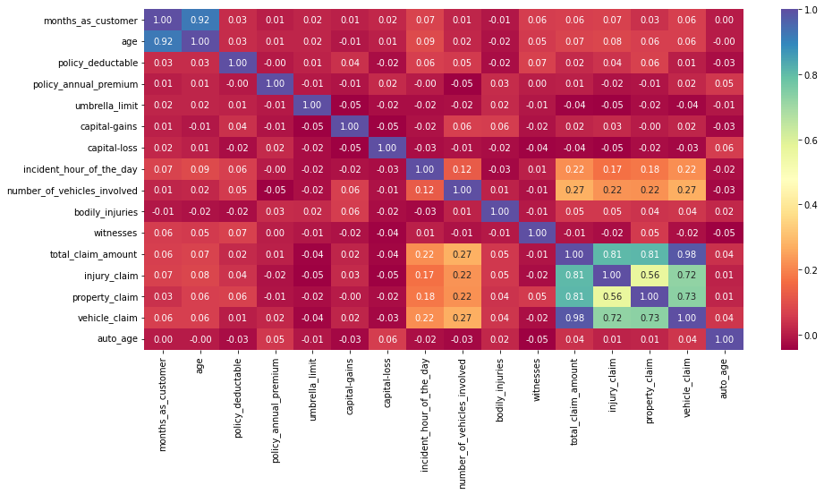

```python
# Checking correlation
plt.figure(figsize = (15, 7))

sns.heatmap(data1.corr(), annot = True, fmt = ".2f", cmap = "Spectral")
```

#### --> Findings:

#### (1) Injury_claim, Property_cliam and vehicle_claim are all correlated to total_claim_amount. Maybe total_claim_amount are the summation of those 3 variables.

#### (2) As expected, number_of_vehicles_involved shows some correlationship to above 4 claim values.

```python
# Function to plot stacked bar plots
def stacked_barplot(data, predictor, target):
    """
    Print the category counts and plot a stacked bar chart

    data: dataframe

    predictor: independent variable

    target: target variable
    """
    count = data[predictor].nunique()

    sorter = data[target].value_counts().index[-1]

    tab1 = pd.crosstab(data[predictor], data[target], margins = True).sort_values(
        by = sorter, ascending = False
    )
    print("<<",predictor," by ",target, ">>")

    print(tab1)

    print("-" * 80)

    tab = pd.crosstab(data[predictor], data[target], normalize = "index").sort_values(
        by = sorter, ascending = False
    )

    tab.plot(kind = "bar", stacked = True, figsize = (count + 1, 5))

    plt.legend(
        loc = "lower left",
        frameon = False,
    )

    plt.legend(loc = "upper left", bbox_to_anchor = (1, 1))

    plt.show()
```

```
<< insured_hobbies  by  fraud_reported >>
fraud_reported     N    Y   All
insured_hobbies
All              753  247  1000
chess              8   38    46
cross-fit          9   26    35
reading           47   17    64
yachting          37   16    53
board-games       34   14    48
paintball         44   13    57
polo              34   13    47
base-jumping      36   13    49
hiking            40   12    52
exercise          46   11    57
skydiving         38   11    49
video-games       40   10    50
movies            46    9    55
bungie-jumping    47    9    56
sleeping          33    8    41
golf              49    6    55
basketball        28    6    34
kayaking          49    5    54
dancing           38    5    43
camping           50    5    55
--------------------------------------------------------------------------------
```

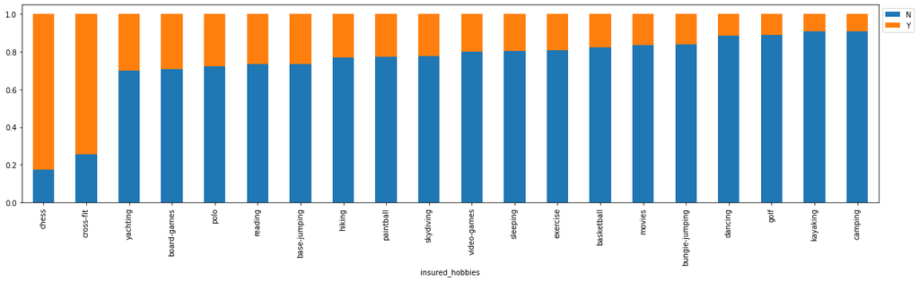

```
<< incident_severity  by  fraud_reported >>
fraud_reported       N    Y   All
incident_severity
All                753  247  1000
Major Damage       109  167   276
Minor Damage       316   38   354
Total Loss         244   36   280
Trivial Damage      84    6    90
--------------------------------------------------------------------------------
```

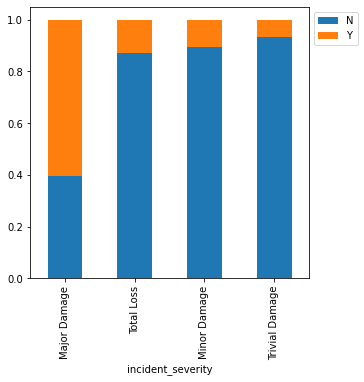

```
<< incident_type  by  fraud_reported >>
fraud_reported              N    Y   All
incident_type
All                       753  247  1000
Single Vehicle Collision  286  117   403
Multi-vehicle Collision   305  114   419
Parked Car                 76    8    84
Vehicle Theft              86    8    94
--------------------------------------------------------------------------------
```

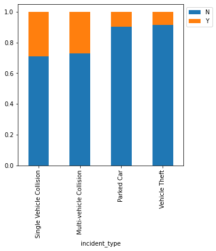

```python
# Regenerating a few interesting graph for demonstration:
for i in ["insured_hobbies","incident_severity","incident_type"]:
    stacked_barplot(data1, i, "fraud_reported")
```

### Prepare data for modeling

#### Encoding categorical variables

```python
# Creating dummy variables for the categorical columns, drop_first = True is used to avoid redundant variables
data2 = pd.get_dummies(
    data1,
    columns = data1.select_dtypes(include = ["object", "category"]).columns.tolist(),
    drop_first = True,
)
```

```python
data2.head()
```

|  | months_as_customer | age | policy_deductable | policy_annual_premium | umbrella_limit | capital-gains | capital-loss | incident_hour_of_the_day | number_of_vehicles_involved | bodily_injuries | witnesses | total_claim_amount | injury_claim | property_claim | vehicle_claim | auto_age | policy_state_IN | policy_state_OH | policy_csl_250/500 | policy_csl_500/1000 | insured_sex_MALE | insured_education_level_College | insured_education_level_High School | insured_education_level_JD | insured_education_level_MD | insured_education_level_Masters | insured_education_level_PhD | insured_occupation_armed-forces | insured_occupation_craft-repair | … |
| --- | --- | --- | --- | --- | --- | --- | --- | --- | --- | --- | --- | --- | --- | --- | --- | --- | --- | --- | --- | --- | --- | --- | --- | --- | --- | --- | --- | --- | --- | --- |
| 0 | 328 | 48 | 1000 | 1406.910 | 0 | 53300 | 0 | 5 | 1 | 1 | 2 | 71610 | 6510 | 13020 | 52080 | 19 | 0 | 1 | 1 | 0 | 1 | 0 | 0 | 0 | 1 | 0 | 0 | 0 | 1 | … |
| 1 | 228 | 42 | 2000 | 1197.220 | 5000000 | 0 | 0 | 8 | 1 | 0 | 0 | 5070 | 780 | 780 | 3510 | 16 | 1 | 0 | 1 | 0 | 1 | 0 | 0 | 0 | 1 | 0 | 0 | 0 | 0 | … |
| 2 | 134 | 29 | 2000 | 1413.140 | 5000000 | 35100 | 0 | 7 | 3 | 2 | 3 | 34650 | 7700 | 3850 | 23100 | 16 | 0 | 1 | 0 | 0 | 0 | 0 | 0 | 0 | 0 | 0 | 1 | 0 | 0 | … |
| 3 | 256 | 41 | 2000 | 1415.740 | 6000000 | 48900 | -62400 | 5 | 1 | 1 | 2 | 63400 | 6340 | 6340 | 50720 | 9 | 0 | 0 | 1 | 0 | 0 | 0 | 0 | 0 | 0 | 0 | 1 | 1 | 0 | … |
| 4 | 228 | 44 | 1000 | 1583.910 | 6000000 | 66000 | -46000 | 20 | 1 | 0 | 1 | 6500 | 1300 | 650 | 4550 | 14 | 0 | 0 | 0 | 1 | 1 | 0 | 0 | 0 | 0 | 0 | 0 | 0 | 0 | … |

#### Split Independent variables (X) and Dependent variable (Y)

```python
Y = data2.fraud_reported_Y
X = data2.drop(columns = ['fraud_reported_Y'])
```

#### Scaling the data

```python
# Scaling the data
sc = StandardScaler()

X_scaled = sc.fit_transform(X)

X_scaled = pd.DataFrame(X_scaled, columns = X.columns)
```

#### Split the data into training and test datasets

```python
x_train, x_test, y_train, y_test = train_test_split(X_scaled, Y, test_size = 0.3, random_state = 1, stratify = Y)
```

```python
print("x_train", x_train.shape)
print("y_train",y_train.shape)
print("x_test",x_test.shape)
print("y_test",y_test.shape)
```

```
x_train (700, 141)

y_train (700,)

x_test (300, 141)

y_test (300,)
```

### Decide Model Evaluation Criterion

- False Positive: predict a claim as a fraud, but it turns out that it was not a fraud.
- False Negative: Identify a claim as a genuine claim, but it turns out that it was a fruad and insurance company lost money.
- It looks like false negative cases will damage an insurance company more than false positive cases. Therefore, we need to build a model that minimize the false negative or maximize recall of the fraud=1 case.

### model evaluation matrix

```python
def metrics_score(actual, predicted):

    print(classification_report(actual, predicted))

    cm = confusion_matrix(actual, predicted)

    plt.figure(figsize = (8, 5))

    sns.heatmap(cm, annot = True, fmt = '.2f', xticklabels = ['Not Fraud', 'Fraud'], yticklabels = ['Not Fraud', 'Fraud'],cmap="PiYG")

    plt.ylabel('Actual')

    plt.xlabel('Predicted')

    plt.show()
```

```python
def model_performance_classification(model, predictors, target):
    """
    Function to compute different metrics to check classification model performance

    model: classifier

    predictors: independent variables

    target: dependent variable
    """

    # Predicting using the independent variables
    pred = model.predict(predictors)

    overall_recall = recall_score(target, pred,average = 'macro')                 # To compute recall

    overall_precision = precision_score(target, pred, average = 'macro')              # To compute precision

    acc = accuracy_score(target, pred)                                 # To compute accuracy score

    f1=f1_score(target, pred, average = 'macro')

    focus_recall = recall_score(target, pred, pos_label=1)
    focus_precision = precision_score(target, pred, pos_label=1)
    focus_f1_score=f1_score(target, pred, pos_label=1)

    # Creating a dataframe of metrics

    df_perf = pd.DataFrame(
        {
            "Overall Precision":  overall_precision,
            "Overall Recall":  overall_recall,
            "Overall Accuracy": acc,
            "Overall F1 Score":f1,
            "focus_precision":focus_precision,
            "focus_recall": focus_recall,
            "focus_F1_score":focus_f1_score

        },

        index = [0],
    )

    return df_perf
```

```python
def relative_plot(model,predictors ):

    importances = model.feature_importances_
    columns=predictors.columns
    importance_df = pd.DataFrame(importances, index = columns, columns = ['Importance']).sort_values(by = 'Importance', ascending = False)
    plt.figure(figsize = (13, 13))
    sns.barplot(importance_df.Importance,importance_df.index)
    print(importance_df)
    plt.show()
```

### Build models

#### 1. Logistic Regression

```python
# Run a logistic regression using a train dataset
lg = LogisticRegression()
lg.fit(x_train,y_train)
logistic_train = model_performance_classification(lg,x_train,y_train)
logistic_test = model_performance_classification(lg,x_test,y_test)
logistic_train["data source"]="training data"
logistic_test["data source"]="test data"
logistic_performance1 = pd.concat([logistic_train, logistic_test], axis=0)
logistic_performance1["Model"]="Logistic Regreession"
print(logistic_performance1.T)
```

```
                                      0                     0

Overall Precision                 0.879                 0.736

Overall Recall                    0.849                 0.738

Overall Accuracy                  0.901                 0.803

Overall F1 Score                  0.862                 0.737

focus_precision                   0.838                 0.600

focus_recall                      0.746                 0.608

focus_F1_score                    0.789                 0.604

data source               training data             test data

Model              Logistic Regreession  Logistic Regreession
```

#### Logistic model finding:

#### The model exhibits 90% of accuracy with the traing data and 80% of accuracy with the test data. However, the recall rates are 75% with the training data and 61% wth the test data.

#### 2. KNN

#### Decide the level of K

```python
knn = KNeighborsClassifier()
params_knn = {'n_neighbors': np.arange(3, 20), 'weights': ['uniform', 'distance'], 'p': [1, 2]}

grid_knn = GridSearchCV(estimator = knn, param_grid = params_knn, scoring = 'recall', cv = 10)

model_knn = grid_knn.fit(x_train,y_train)

knn_tuned = model_knn.best_estimator_

print(knn_tuned)
```

```
KNeighborsClassifier(n_neighbors=3, p=1)
```

#### --> Finding: Recommendation K=3, p=1

#### Apply the recommended parameter values

```python
# Training data
knn_tuned.fit(x_train, y_train)
KNN_train = model_performance_classification(knn_tuned,x_train,y_train)
KNN_test = model_performance_classification(knn_tuned,x_test,y_test)
KNN_train["data source"]="training data"
KNN_test["data source"]="test data"
KNN_performance1 = pd.concat([KNN_train, KNN_test], axis=0)
KNN_performance1["Model"]="KNN=3"
print(KNN_performance1)
```

```
   Overall Precision  Overall Recall  Overall Accuracy  Overall F1 Score  \

0              0.768           0.705             0.819             0.726

0              0.553           0.542             0.693             0.543



   focus_precision  focus_recall  focus_F1_score    data source  Model

0            0.692         0.480           0.567  training data  KNN=3

0            0.333         0.243           0.281      test data  KNN=3
```

#### --> Finding: The recall rate for the fraud case is quite low and the model is overfitting the training data

#### 3. LDA and QDA

```python
# Fitting the LDA model
lda = LinearDiscriminantAnalysis()
lda.fit(x_train, y_train)
lda_train = model_performance_classification(lda,x_train,y_train)
lda_test = model_performance_classification(lda,x_test,y_test)
lda_train["data source"]="training data"
lda_test["data source"]="test data"
lda_performance1 = pd.concat([lda_train, lda_test], axis=0)
lda_performance1["Model"]="LDA"
print(lda_performance1.T)
```

```
                               0          0

Overall Precision          0.859      0.779

Overall Recall             0.861      0.801

Overall Accuracy           0.896      0.837

Overall F1 Score           0.860      0.789

focus_precision            0.787      0.651

focus_recall               0.792      0.730

focus_F1_score             0.790      0.688

data source        training data  test data

Model                        LDA        LDA
```

```python
# Fitting the QDA model
qda = QuadraticDiscriminantAnalysis()
qda.fit(x_train, y_train)
qda_train = model_performance_classification(qda,x_train,y_train)
qda_test = model_performance_classification(qda,x_test,y_test)
qda_train["data source"]="training data"
qda_test["data source"]="test data"
qda_performance1 = pd.concat([qda_train, qda_test], axis=0)
qda_performance1["Model"]="QDA"
print(qda_performance1.T)
```

```
                               0          0

Overall Precision          0.964      0.609

Overall Recall             0.980      0.536

Overall Accuracy           0.979      0.747

Overall F1 Score           0.972      0.521

focus_precision            0.934      0.450

focus_recall               0.983      0.122

focus_F1_score             0.958      0.191

data source        training data  test data

Model                        QDA        QDA
```

#### Decision Tree, Random Forest,Adaboost Classifier, Gradient Boost Classifier, Extreme Gradient Boosting(XGBoost)

#### As these tree based and bagging based ensemble models are not affected by the different scales of input variables, we will not standardize the data.

```python
# Split the data
x_train2, x_test2, y_train2, y_test2 = train_test_split(X, Y, test_size = 0.3, random_state = 1, stratify = Y)
```

#### 4. Decision Tree

```python
dt = DecisionTreeClassifier(class_weight = 'balanced', random_state = 1)
dt.fit(x_train2, y_train2)
dtree_train2 = model_performance_classification(dt,x_train2,y_train2)
dtree_test2 = model_performance_classification(dt,x_test2,y_test2)
dtree_train2["data source"]="training data"
dtree_test2["data source"]="test data"

dtree_performance2 = pd.concat([dtree_train2, dtree_test2], axis=0)
dtree_performance2["Model"]="Decision Tree"
print(dtree_performance2.T)
```

```
                               0              0

Overall Precision          1.000          0.714

Overall Recall             1.000          0.745

Overall Accuracy           1.000          0.780

Overall F1 Score           1.000          0.725

focus_precision            1.000          0.543

focus_recall               1.000          0.676

focus_F1_score             1.000          0.602

data source        training data      test data

Model              Decision Tree  Decision Tree
```

#### 5. Random Forest

```python
rf = RandomForestClassifier(class_weight = 'balanced', random_state = 1)
rf.fit(x_train2, y_train2)
rf_train2 = model_performance_classification(rf,x_train2,y_train2)
rf_test2 = model_performance_classification(rf,x_test2,y_test2)
rf_train2["data source"]="training data"
rf_test2["data source"]="test data"

rf_performance2 = pd.concat([rf_train2, rf_test2], axis=0)
rf_performance2["Model"]="Random Forest"
print(rf_performance2.T)
```

```
                               0              0

Overall Precision          1.000          0.634

Overall Recall             1.000          0.536

Overall Accuracy           1.000          0.753

Overall F1 Score           1.000          0.516

focus_precision            1.000          0.500

focus_recall               1.000          0.108

focus_F1_score             1.000          0.178

data source        training data      test data

Model              Random Forest  Random Forest
```

#### 6. Ada booster classifier

```python
# Adaboost Classifier
adaboost = AdaBoostClassifier(random_state = 1)
adaboost.fit(x_train2, y_train2)
ada_train2 = model_performance_classification(adaboost,x_train2,y_train2)
ada_test2 = model_performance_classification(adaboost,x_test2,y_test2)
ada_train2["data source"]="training data"
ada_test2["data source"]="test data"

ada_performance2 = pd.concat([ada_train2, ada_test2], axis=0)
ada_performance2["Model"]="Ada Booster"
print(ada_performance2.T)
```

```
                               0            0

Overall Precision          0.860        0.731

Overall Recall             0.812        0.699

Overall Accuracy           0.883        0.800

Overall F1 Score           0.832        0.712

focus_precision            0.823        0.617

focus_recall               0.671        0.500

focus_F1_score             0.739        0.552

data source        training data    test data

Model                Ada Booster  Ada Booster
```

#### 7. Gradient Booster Classifier

```python
# Gradient Boost Classifier
gbc = GradientBoostingClassifier(random_state = 1)
gbc.fit(x_train2, y_train2)
gbc_train2 = model_performance_classification(gbc,x_train2,y_train2)
gbc_test2 = model_performance_classification(gbc,x_test2,y_test2)
gbc_train2["data source"]="training data"
gbc_test2["data source"]="test data"

gbc_performance2 = pd.concat([gbc_train2, gbc_test2], axis=0)
gbc_performance2["Model"]="Gradient Booster"
print(gbc_performance2.T)
```

```
                                  0                 0

Overall Precision             0.974             0.744

Overall Recall                0.953             0.742

Overall Accuracy              0.973             0.810

Overall F1 Score              0.963             0.743

focus_precision               0.975             0.616

focus_recall                  0.913             0.608

focus_F1_score                0.943             0.612

data source           training data         test data

Model              Gradient Booster  Gradient Booster
```

#### 8. XGBooster

```python
# XGBoost Classifier
xgb = XGBClassifier(random_state = 1, eval_metric = 'logloss')
xgb.fit(x_train2,y_train2)
xgb_train2 = model_performance_classification(xgb,x_train2,y_train2)
xgb_test2 = model_performance_classification(xgb,x_test2,y_test2)
xgb_train2["data source"]="training data"
xgb_test2["data source"]="test data"

xgb_performance2 = pd.concat([xgb_train2, xgb_test2], axis=0)
xgb_performance2["Model"]="XG Booster"
print(xgb_performance2.T)
```

```
                               0           0

Overall Precision          1.000       0.708

Overall Recall             1.000       0.706

Overall Accuracy           1.000       0.783

Overall F1 Score           1.000       0.707

focus_precision            1.000       0.562

focus_recall               1.000       0.554

focus_F1_score             1.000       0.558

data source        training data   test data

Model                 XG Booster  XG Booster
```

#### Combine the performances

```python
performance_collection1=pd.concat([logistic_performance1,KNN_performance1,lda_performance1,qda_performance1,dtree_performance2,rf_performance2,ada_performance2,gbc_performance2,xgb_performance2],axis=0)
```

```python
print(performance_collection1[["Model","data source","focus_recall"]])
```

```
                  Model    data source  focus_recall

0  Logistic Regreession  training data         0.746

0  Logistic Regreession      test data         0.608

0                 KNN=3  training data         0.480

0                 KNN=3      test data         0.243

0                   LDA  training data         0.792

0                   LDA      test data         0.730

0                   QDA  training data         0.983

0                   QDA      test data         0.122

0         Decision Tree  training data         1.000

0         Decision Tree      test data         0.676

0         Random Forest  training data         1.000

0         Random Forest      test data         0.108

0           Ada Booster  training data         0.671

0           Ada Booster      test data         0.500

0      Gradient Booster  training data         0.913

0      Gradient Booster      test data         0.608

0            XG Booster  training data         1.000

0            XG Booster      test data         0.554
```

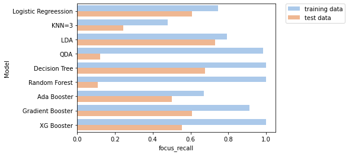

```python
sns.barplot(x = "focus_recall", y = "Model", hue = "data source", data = performance_collection1,palette='pastel')
plt.legend(bbox_to_anchor=(1.05, 1), loc=2, borderaxespad=0.)
plt.show()
```

#### --> Finding: Based on the Fraud=1 recall rate, LDA performs the best and it does not overfit the training data that much either.

#### We may want to see whether we can improve its and other competitive models performances by hyperparameter tunning and learn the important indicating variables from the final model.

#### LDA Hyperparameters Tunning

```python
LinearDiscriminantAnalysis()
```

LDA default setting: LinearDiscriminantAnalysis( solver='svd', shrinkage=None, n_components=None, store_covariance=False, tol=0.0001 )

```python
lda_tuned = LinearDiscriminantAnalysis()

# Define the hyperparameter grid
param_grid = {
    'solver': ['svd', 'lsqr', 'eigen'],
    'n_components': [None,1, 2, 3, 4],
    'shrinkage': [None, 'auto'],
    'tol': [0.0001, 0.001, 0.01]
}

# Create the grid search object
grid_search = GridSearchCV(lda_tuned, param_grid, cv=4, verbose=1)

# Fit the grid search to the data
grid_search.fit(x_train, y_train)

# Print the best parameters
print(grid_search.best_params_)

# Set the classifier to the best combination of parameters
lda_tuned_2 = grid_search.best_estimator_
```

```
Fitting 4 folds for each of 90 candidates, totalling 360 fits

{'n_components': None, 'shrinkage': None, 'solver': 'lsqr', 'tol': 0.0001}
```

```python
# Fitting the tuned LDA model
lda_tuned_train = model_performance_classification(lda_tuned_2,x_train,y_train)
lda_tuned_test = model_performance_classification(lda_tuned_2,x_test,y_test)
lda_tuned_train["data source"]="training data"
lda_tuned_test["data source"]="test data"
lda_tuned_performance1 = pd.concat([lda_tuned_train, lda_tuned_test], axis=0)
lda_tuned_performance1["Model"]="LDA_tuned"
print(lda_tuned_performance1.T)
```

```
                               0          0

Overall Precision          0.859      0.779

Overall Recall             0.861      0.801

Overall Accuracy           0.896      0.837

Overall F1 Score           0.860      0.789

focus_precision            0.787      0.651

focus_recall               0.792      0.730

focus_F1_score             0.790      0.688

data source        training data  test data

Model                  LDA_tuned  LDA_tuned
```

#### --> Finding: the tunned hyperparameter values are almost the same with the default setting and understandably, the performance of tuned LDA did not improve that much from the original LDA. Let's check whether the recall performance can be improved if we change the threshold value.

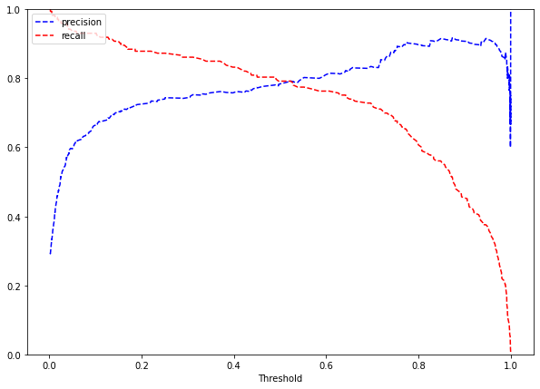

```
The new threshold to test is  418   0.523

Name: threshold, dtype: float64
```

```python
y_scores_lda_tuned = lda_tuned_2.predict_proba(x_train)

precisions_lda, recalls_lda, thresholds_lda = precision_recall_curve(y_train, y_scores_lda_tuned[:, 1])

# Plot values of precisions, recalls, and thresholds
# The last precision and recall values are 1. and 0. respectively and do not have a corresponding threshold.
plt.figure(figsize = (10, 7))

plt.plot(thresholds_lda, precisions_lda[:-1], 'b--', label = 'precision')

plt.plot(thresholds_lda, recalls_lda[:-1], 'r--', label = 'recall')

plt.xlabel('Threshold')

plt.legend(loc = 'upper left')

plt.ylim([0, 1])

plt.show()


# find the meeting point between precision and recall
pre_recl_df = pd.DataFrame()
pre_recl_df['precision'] = precisions_lda[:-1]
pre_recl_df['recall'] = recalls_lda[:-1]
pre_recl_df['threshold'] = list(thresholds_lda)


threshold_point = pre_recl_df['threshold'].loc[pre_recl_df['recall'] ==pre_recl_df['precision']]
print("The new threshold to test is ",threshold_point)
```

#### --> finding: The new threshold is 0.523 which is almost the same with the default threshold 0.5. No need to proceed further.

#### Gradient Booster Hyperparameter Tunning

```python
# defalut setting: This means that the model will use a "deviance" loss function,
# a learning rate of 0.1, and 100 trees in the ensemble.
#The model will also use a maximum depth of 3 for each tree and will split a node
# if the impurity is above a certain threshold (as determined by the "friedman_mse" criterion).

# Set up the parameters for the gradient boosting model
parameters = {
    'n_estimators': [100, 200, 300],
    'max_depth': [3, 5, 7],
    'learning_rate': [0.1, 0.05, 0.2]
}

# Type of scoring used to compare parameter combinations - recall score for class 1
scorer = metrics.make_scorer(recall_score, pos_label = 1)

# Initialize the gradient boosting model
gbc_tuned = GradientBoostingClassifier(random_state = 1)

# Set up the grid search cross-validation
grid_search = GridSearchCV(gbc_tuned, parameters, cv=4, scoring=scorer, return_train_score=True)

# Run the grid search
grid_search.fit(x_train,y_train)

# Set the classifier to the best combination of parameters
gbc_tuned_2 = grid_search.best_estimator_


# Print the best hyperparameter values
print("Best parameters:", grid_search.best_params_)

# Print the best cross-validation score
print("Best cross-validation score:", grid_search.best_score_)
```

```
Best parameters: {'learning_rate': 0.05, 'max_depth': 3, 'n_estimators': 200}

Best cross-validation score: 0.6075581395348837
```

```python
gbc_tuned_train2 = model_performance_classification(gbc_tuned_2,x_train2,y_train2)
gbc_tuned_test2 = model_performance_classification(gbc_tuned_2,x_test2,y_test2)
gbc_tuned_train2["data source"]="training data"
gbc_tuned_test2["data source"]="test data"

gbc_tuned_performance2 = pd.concat([gbc_tuned_train2, gbc_tuned_test2], axis=0)
gbc_tuned_performance2["Model"]="Gradient Booster Tuned"
print(gbc_tuned_performance2.T)
```

```
                                        0                       0

Overall Precision                   0.577                   0.595

Overall Recall                      0.582                   0.607

Overall Accuracy                    0.447                   0.477

Overall F1 Score                    0.447                   0.475

focus_precision                     0.289                   0.303

focus_recall                        0.850                   0.865

focus_F1_score                      0.432                   0.449

data source                 training data               test data

Model              Gradient Booster Tuned  Gradient Booster Tuned
```

#### Decision Tree Hyperparameter Tunning

< Default setting> DecisionTreeClassifier( criterion='gini', splitter='best', max_depth=None, min_samples_split=2, min_samples_leaf=1, min_weight_fraction_leaf=0.0, max_features=None, random_state=None, max_leaf_nodes=None, min_impurity_decrease=0.0, min_impurity_split=None, class_weight=None, presort='deprecated', ccp_alpha=0.0 )

```python
# Choose the type of classifier
dtree_tuned = DecisionTreeClassifier(class_weight = 'balanced', random_state = 1)

# Grid of parameters to choose from
parameters = {'max_depth': np.arange(2, 7),
              'criterion': ['gini', 'entropy'],
              'min_samples_leaf': [2,5, 10, 20, 25]
             }

# Type of scoring used to compare parameter combinations
recall_scorer = metrics.make_scorer(recall_score, pos_label = 1)

# Run the grid search
gridCV = GridSearchCV(dtree_tuned, parameters, scoring = recall_scorer, cv = 4)

# Fitting the grid search on the train data
gridCV = gridCV.fit(x_train2, y_train2)

# Set the classifier to the best combination of parameters
dtree_tuned_2 = gridCV.best_estimator_

# Print the best hyperparameter values
print("Best parameters:", gridCV .best_params_)
```

```
Best parameters: {'criterion': 'gini', 'max_depth': 4, 'min_samples_leaf': 5}
```

```python
dtree_tuned_2.fit(x_train2, y_train2)
dtree_tuned_train2 = model_performance_classification(dtree_tuned_2,x_train2,y_train2)
dtree_tuned_test2 = model_performance_classification(dtree_tuned_2,x_test2,y_test2)
dtree_tuned_train2["data source"]="training data"
dtree_tuned_test2["data source"]="test data"

dtree_tuned_performance2 = pd.concat([dtree_tuned_train2, dtree_tuned_test2], axis=0)
dtree_tuned_performance2["Model"]="Decision Tree Tuned"
print(dtree_tuned_performance2.T)
```

```
                                     0                    0

Overall Precision                0.812                0.741

Overall Recall                   0.858                0.792

Overall Accuracy                 0.863                0.797

Overall F1 Score                 0.829                0.756

focus_precision                  0.677                0.563

focus_recall                     0.850                0.784

focus_F1_score                   0.754                0.655

data source              training data            test data

Model              Decision Tree Tuned  Decision Tree Tuned
```

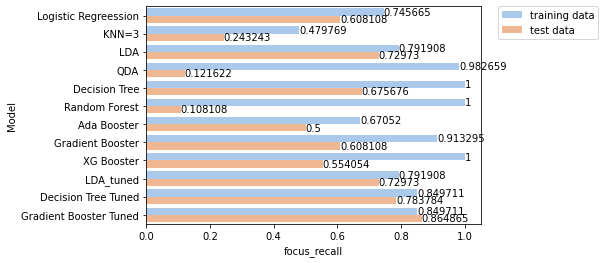

```python
ax=sns.barplot(x = "focus_recall", y = "Model", hue = "data source", data = performance_collection2,palette='pastel')
plt.legend(bbox_to_anchor=(1.05, 1), loc=2, borderaxespad=0.)
for i in ax.containers:
    ax.bar_label(i,)
plt.show()
```

#### --> conclusion:

#### Tuned gradient booster demonstrates the best recall rate with the test data and its performance with the training data is not that different. Let's see which variables are important with the gradient booster model.

#### Identify important variables in the gradient booster model framework

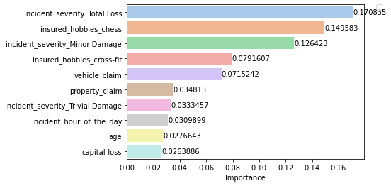

```python
importances = gbc_tuned_2.feature_importances_
columns = x_train2.columns
importance_df = pd.DataFrame(importances, index = columns, columns = ['Importance']).sort_values(by = 'Importance', ascending = False)

ax=sns.barplot(importance_df.Importance[:10], importance_df.index[:10],palette='pastel')
plt.legend(bbox_to_anchor=(1.05, 1), loc=2, borderaxespad=0.)
for i in ax.containers:
    ax.bar_label(i,)
plt.show()
```

```python
# Fitting the Explainer
explainer = sh.Explainer(gbc_tuned_2.predict, x_test2)

# Calculating the SHAP values.
shap_values = explainer(x_test)
```

```
Permutation explainer: 301it [00:35,  6.48it/s]
```

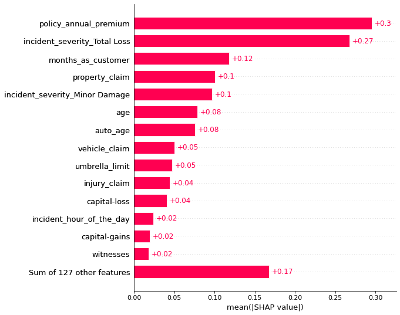

```python
sh.plots.bar(shap_values,max_display=15)
```

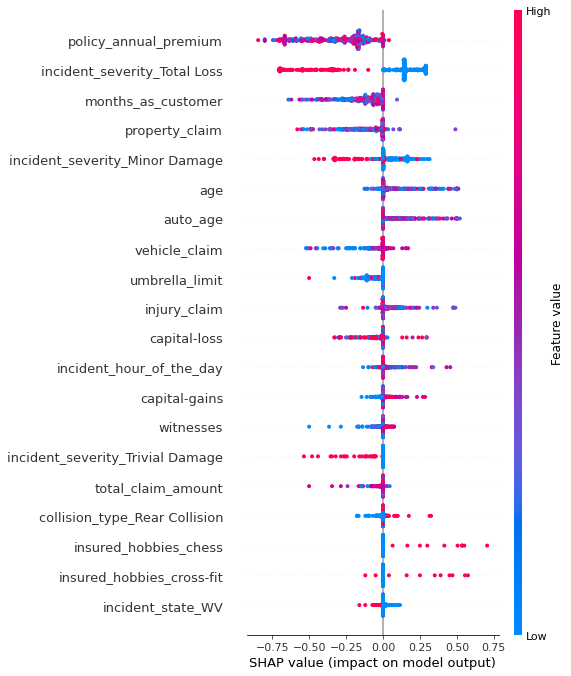

```python
sh.summary_plot(shap_values)
```